# Class 11: Transcriptomics and the analysis of RNA-Seq data

Taylor F. (A59010460)

2/23/2022

# Installing DESeq2

```r
#Do this in the console in the future
#install.packages("BiocManager")
#BiocManager::install()

#We will also need the DESeq2 package
#BiocManager::install("DESeq2")

#NOTE: Answer NO to prompts to install from source or update

#Run library(DESeq2) in the console
```

Today we will run differential expression analysis of some published data from Himes et al. where the authors used a published RNA-seq experiment where airway smooth muscle cells were treated with dexamethasone, a synthetic glucocorticoid steroid with anti-inflammatory effects.

# Importing countData and colData

```r
counts <- read.csv("airway_scaledcounts.csv", row.names=1)
metadata <- read.csv("airway_metadata.csv")

#Preview the counts dataset
head(counts)
```

```
##                 SRR1039508 SRR1039509 SRR1039512 SRR1039513 SRR1039516
## ENSG00000000003        723        486        904        445       1170
## ENSG00000000005          0          0          0          0          0
## ENSG00000000419        467        523        616        371        582
## ENSG00000000457        347        258        364        237        318
## ENSG00000000460         96         81         73         66        118
## ENSG00000000938          0          0          1          0          2
##                 SRR1039517 SRR1039520 SRR1039521
## ENSG00000000003       1097        806        604
## ENSG00000000005          0          0          0
## ENSG00000000419        781        417        509
## ENSG00000000457        447        330        324
## ENSG00000000460         94        102         74
## ENSG00000000938          0          0          0
```

```r
#Determine how many genes are in this counts dataset
nrow(counts)
```

```
## [1] 38694
```

```r
#Determine how many control cell lines used
ncol(counts)
```

```
## [1] 8
```

```r
#Look at the metadata dataset
metadata
```

```
##           id     dex celltype     geo_id
## 1 SRR1039508 control   N61311 GSM1275862
## 2 SRR1039509 treated   N61311 GSM1275863
## 3 SRR1039512 control  N052611 GSM1275866
## 4 SRR1039513 treated  N052611 GSM1275867
## 5 SRR1039516 control  N080611 GSM1275870
## 6 SRR1039517 treated  N080611 GSM1275871
## 7 SRR1039520 control  N061011 GSM1275874
## 8 SRR1039521 treated  N061011 GSM1275875
```

Question 1:

There are 38694 rows, which translate to genes, in the counts dataset.

Question 2:

Based on the metadata, it looks like we have four drug-treated and four control cell lines. Our first question is does the drug do anything?

First, we want to check if the metadata matches the counts data order:

```r
#Grab the id column values of the metadata dataset
metadata$id
```

```
## [1] "SRR1039508" "SRR1039509" "SRR1039512" "SRR1039513" "SRR1039516"
## [6] "SRR1039517" "SRR1039520" "SRR1039521"
```

```r
#Grab the column names of the counts dataset
colnames(counts)
```

```
## [1] "SRR1039508" "SRR1039509" "SRR1039512" "SRR1039513" "SRR1039516"
## [6] "SRR1039517" "SRR1039520" "SRR1039521"
```

```r
#Ask if these values are equivalent (all returned values should be TRUE)
metadata$id == colnames(counts)
```

```
## [1] TRUE TRUE TRUE TRUE TRUE TRUE TRUE TRUE
```

```r
#Alternative method
all(metadata$id == colnames(counts))
```

```
## [1] TRUE
```

```r
#Fancy method
if(all(metadata$id == colnames(counts))) {cat("Let's do this!")}
```

```
## Let's do this!
```

Next, we want to separate the two conditions (control and treated) from “counts” and use a summary statistic to make comparison easier.

```r
#Control first
#We need to find the ID associated with control conditions (i.e. which id columns also have dex == "control") and then report only the ID of these samples
control.inds <- metadata[metadata$dex == "control","id"]
control.inds
```

```
## [1] "SRR1039508" "SRR1039512" "SRR1039516" "SRR1039520"
```

```r
#We now use these indices to search through counts and finds these columns
control.counts <- counts[,control.inds]
head(control.counts)
```

```
##                 SRR1039508 SRR1039512 SRR1039516 SRR1039520
## ENSG00000000003        723        904       1170        806
## ENSG00000000005          0          0          0          0
## ENSG00000000419        467        616        582        417
## ENSG00000000457        347        364        318        330
## ENSG00000000460         96         73        118        102
## ENSG00000000938          0          1          2          0
```

```r
#Question 4: We can now access the treated values, too
treated.inds <- metadata[metadata$dex == "treated","id"]
treated.inds
```

```
## [1] "SRR1039509" "SRR1039513" "SRR1039517" "SRR1039521"
```

```r
treated.counts <- counts[,treated.inds]
head(treated.counts)
```

```
##                 SRR1039509 SRR1039513 SRR1039517 SRR1039521
## ENSG00000000003        486        445       1097        604
## ENSG00000000005          0          0          0          0
## ENSG00000000419        523        371        781        509
## ENSG00000000457        258        237        447        324
## ENSG00000000460         81         66         94         74
## ENSG00000000938          0          0          0          0
```

Find the mean count value for each row (i.e. gene). We could use the ‘apply()’ function or more simply the ‘rowMeans()’ function.

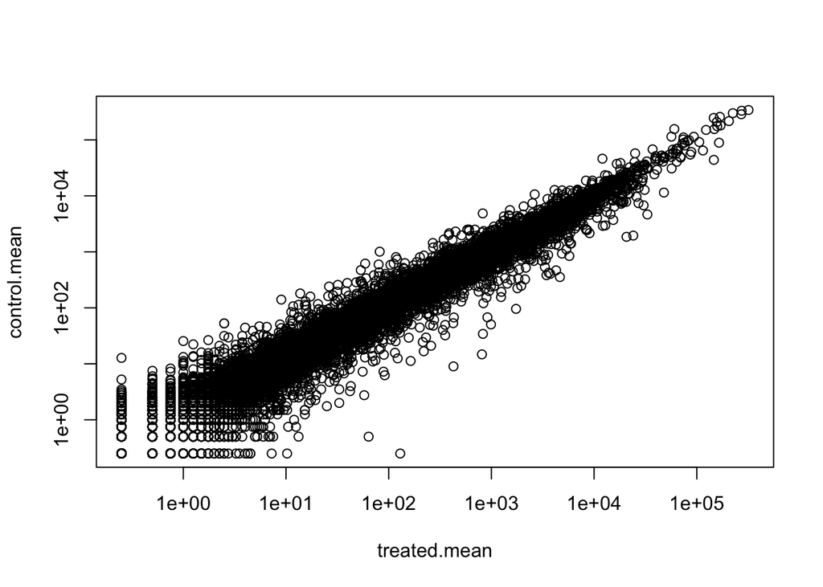

```r
#Let's now find the means for each of these groups
control.mean <- rowMeans(control.counts)
treated.mean <- rowMeans(treated.counts)

#Question 5a: We can plot these mean values against one another
plot(treated.mean, control.mean, log = "xy")
#Question 5b: We can also use ggplot
library(ggplot2)
```

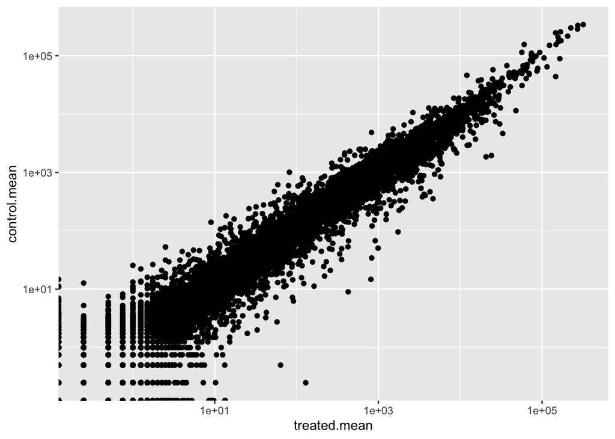

```r
ggplot(counts, aes(treated.mean, control.mean)) + geom_point() + scale_y_continuous(trans='log10') + scale_x_continuous(trans='log10')
```

```r
#Question 6: Try plotting both axes on a log scale. What is the argument to plot() that allows you to do this?
#log = "xy"
```

We often use log 2 transformation because it is easier to understand, visually.

```r
#20/20
#log2(20/20)
#log2(40/20)
#log2(10/20)
#log2(80/20)

#Store the log2 fold change between treated and control groups
log2fc <- log2(treated.mean/control.mean)
```

Finding and filtering zero values

```r
#We need to find and remove the genes that have zeros for values
log2fc[1:6]
```

```
## ENSG00000000003 ENSG00000000005 ENSG00000000419 ENSG00000000457 ENSG00000000460
##     -0.45303916             NaN      0.06900279     -0.10226805     -0.30441833
## ENSG00000000938
##            -Inf
```

```r
meancounts <- data.frame(control.mean, treated.mean, log2fc)
head(meancounts[,1:2] == 0)
```

```
##                 control.mean treated.mean
## ENSG00000000003        FALSE        FALSE
## ENSG00000000005         TRUE         TRUE
## ENSG00000000419        FALSE        FALSE
## ENSG00000000457        FALSE        FALSE
## ENSG00000000460        FALSE        FALSE
## ENSG00000000938        FALSE         TRUE
```

```r
z <- data.frame(x = c(1,2,0,4), y = c(1,2,0,0))

#Report which indices are TRUE and FALSE (i.e. sum to 0 or greater than 0) and gives index information
which(z == 0, arr.ind = TRUE)
```

```
##      row col
## [1,]   3   1
## [2,]   3   2
## [3,]   4   2
```

```r
unique(which(z == 0, arr.ind = TRUE)[,"row"])
```

```
## [1] 3 4
```

```r
#Apply this principle to the meancounts dataset
to.rm <- sort(unique(which(meancounts[,1:2] == 0, arr.ind = TRUE)[,"row"]))
mycounts <- meancounts[-to.rm,]
#mycounts
```

There are 21817 genes left over after removing zero values.

How many genes have a log2fc more than +2 (i.e. upregulated)?

```r
up.ind <- mycounts$log2fc > 2
down.ind <- mycounts$log2fc < (-2)
sum(up.ind)
```

```
## [1] 250
```

```r
sum(down.ind)
```

```
## [1] 367
```

There are 250 genes upregulated by at least 2log2